# Combined analysis of Near/Mid tasks from Study 1 and Study 2

George Kinnear

11/08/2021

```r
library(tidyverse)

#Plots
library(ggplot2)
library(patchwork) # for combining plots
library(ggtext) # for markdown in plots
library(latex2exp) # for formatting latex in plot captions

# For Bayesian stats:
library(bayestestR)
#library(insight)
#library(see)
library(rstanarm)
library(tidybayes)
#library(BayesFactor)
ci_width = 0.95  # Use 95% HDIs
set.seed(20210518)

# Tables
library(knitr)
library(kableExtra)
basic_kable = function(df, ...) {
  df %>%
    kable(...) %>%
    kable_styling(bootstrap_options = "striped", full_width = F)
}

# Plot styling
heathers = c("#00b3c3","#e51c24","#016637","#fcb123")
heathers = c("#87005a", "#c66005","#016637","#fcb123")
groupcolours = c("C-CG" = heathers[1],
                 "C-GC" = "#6f004a", # darker heathers1
                 "G-CG" = heathers[2],
                 "G-GC" = "#a34e03" # darker heathers2
                 )
four_groups = c("CCG", "CGC", "GCG", "GGC")
theme_set(theme_minimal())
```

The Near and Mid tasks were unchanged from Study 1 to Study 2, so we combine the student responses from both studies to analyse possible interactions between the tasks, i.e.

> is there any evidence of task order influencing students’ performance?

```r
question_marks = read_csv("data-clean/study1/FAC_LGE-tasks.csv") %>%
  select(question_name, marks_available)

participants <- bind_rows(
  read_csv("data-clean/study1/participants.csv") %>%
    mutate(
      group = str_replace(group, "LGE Group ", ""),
      group = str_glue("study1_{str_sub(group, 1, 1)}-{str_sub(group, 2, 3)}"),
      username = paste0("study1_", username)
    ),
  read_csv("data-clean/study2/participants.csv") %>%
    mutate(
      group = paste0("study2_", str_replace(group, "Group ", "")),
      username = paste0("study1_", username)
    )
)

attempt_data_all = read_rds("data-clean/FAC_LGE-attempt_data.rds")

task_order_data <- bind_rows(
    "study1" = read_rds("data-clean/FAC_LGE-attempt_data.rds"),
    "study2" = read_rds("data-clean/FAC_LGE2-attempt_data.rds"),
    .id = "study"
  ) %>%
  filter(
    str_detect(question_name, "Near|Mid"),
    attempt_number == 1
  ) %>%
  left_join(question_marks, by = "question_name") %>%
  mutate(
    # default to 1 mark per question if not specified
    marks_available = replace_na(marks_available, 1),
    marks_attained = fraction * marks_available,
    # check the time of the attempt to see if it was before the end of the study
    # (since on 2019-11-27, all versions of the materials were made available to all students)
    attempt_time = lubridate::as_datetime(timecreated),
    during_study = case_when(
      study == "study1" ~ attempt_time < lubridate::ymd("2019-11-27"),
      study == "study2" ~ attempt_time < lubridate::ymd("2020-11-27"),
    ),
    group = str_remove_all(group, "LGE Group |Group ")
  ) %>%
  filter(during_study, !is.na(marks_attained)) %>%
  mutate(q_type = if_else(str_detect(question_name, "C"), "C", "G")) %>%
  select(study, group, username, question_name, q_type, questionsummary, responsesummary, marks_attained) %>%
  mutate(task_order = if_else(str_detect(group, "CG$"), "Classify first", "Generate first"))

task_order_data %>%
  select(study, task_order, username) %>%
  distinct() %>%
  janitor::tabyl(study, task_order) %>%
  janitor::adorn_totals(where = "both") %>%
  basic_kable()
```

| study | Classify first | Generate first | Total |
| --- | --- | --- | --- |
| study1 | 46 | 56 | 102 |
| study2 | 52 | 53 | 105 |
| Total | 98 | 109 | 207 |

# Item details

For each item, we have full details of the student response and how it was graded by STACK. Here is an example for each of the tasks:

```r
responses_raw <- task_order_data

responses_raw %>% group_by(question_name) %>% slice_head() %>% basic_kable()
```

study

group

username

question_name

q_type

questionsummary

responsesummary

marks_attained

task_order

study1

GCG

anon100

MidC1

C

${5-3\,n}$ is Decreasing and Bounded above

ans1: “Decreasing” [score]; ans2: “Unbounded” [score]; prt1: ATAlgEquiv_String | prt1-1-T; prt2: ATAlgEquiv_String | prt2-1-F

1

Classify first

study1

GCG

anon100

MidC2

C

${\left(-2\right)^{n+1}}$ is Neither increasing nor decreasing and Unbounded

ans1: “Decreasing” [score]; ans2: “Bounded below” [score]; prt1: ATAlgEquiv_String | prt1-1-F; prt2: ATAlgEquiv_String | prt2-1-F

0

Classify first

study1

GCG

anon100

MidG

G

In each case below, give an example of an arithmetic sequence with the stated property, by entering an expression for the general term. If it is not possible, enter none.

1. Increasing

Â Â Â $u_n=$ [[input:ans1]][[feedback:prt1]] [[validation:ans1]]

2. Decreasing

Â Â Â $u_n=$ [[input:ans2]][[feedback:prt2]] [[validation:ans2]]

3. Bounded above

Â Â Â $u_n=$ [[input:ans3]][[feedback:prt3]] [[validation:ans3]]

(D)Â Decreasing and bounded below

Â Â Â $u_n=$ [[input:ans4]][[feedback:prt4]] [[validation:ans4]]

ans1: 6+3*n [score]; ans2: 5-4*n [score]; ans3: 7-5*n [score]; ans4: none [score]; prt1: ATAlgEquiv_SA_not_logic. | prt1-3-F | ATLogic_True | prt1-1-T | ATGT_true. | prt1-2-T; prt2: ATAlgEquiv_SA_not_logic. | prt2-3-F | ATLogic_True | prt2-1-T | ATGT_true. | prt2-2-T; prt3: ATAlgEquiv_SA_not_logic. | prt3-3-F | ATLogic_True | prt3-1-T | ATGTE_true. | prt3-2-T; prt4: ATEquation_empty | prt4-1-T

4

Classify first

study1

GCG

anon100

NearC

C

${\left[ \frac{1}{4\,n+4} , \mbox{Decreasing} , \mbox{Bounded} \right]}$

ans1: “Decreasing” [score]; ans2: “Bounded” [score]; prt1: ATAlgEquiv_String | prt1-1-T; prt2: ATAlgEquiv_String | prt2-1-T

2

Classify first

study1

GCG

anon100

NearG

G

Give an example of a sequence which is increasing and bounded above.

(Give your answer as a formula for the $n$th term.)

$u_n=$ [[input:ans1]] [[validation:ans1]]

ans1: 1-1/2^n [score]; prt1: ATLogic_True | prt1-1-T | prt1-3-F | ATLogic_True | prt1-4-T

1

Classify first

We process this raw data to extract the answers to each part, and the score.

```r
responses <- responses_raw %>%
  # pick out the various answers - str_match_all returns a matrix, which we have to wrangle a bit
  mutate(ans_bits = str_match_all(responsesummary, "(ans[^:]*): ([^;]*)(?=\\[score\\];)")) %>%
  #mutate(ans_bits = str_match_all(responsesummary, "(ans[:digit:]): ([^;]*)(?=\\[score\\];)")) %>%
  mutate(ans_bits = map(ans_bits, ~ tibble(part = .x[,2], response = .x[,3]))) %>%
  unnest(ans_bits) %>%
  mutate(response = str_remove_all(response, '"')) %>%
  # construct a simplified name for each question part
  mutate(q_part = paste(question_name, part, sep = "_")) %>%
  mutate(
    relevant_prt = case_when(
      # pick out the PRT trace that is relevant to each part, i.e. that grades that answer
      # for these questions, ansN corresponds to prtN in all cases
      TRUE ~ str_match_all(responsesummary, str_glue("prt{parse_number(part)}: [^;]*(?=; |$)")) %>% as.character()
    ),
    fully_correct = case_when(
      # the classification tasks all have very simple PRTs with a single node deciding the mark
      str_detect(question_name, "C") ~ str_detect(relevant_prt, "-1-T"),
      # MidG also has quite simple PRTs
      q_part %in% c("MidG_ans1", "MidG_ans2", "MidG_ans3") ~ str_detect(relevant_prt, "-2-T"),
      q_part == "MidG_ans4" ~ str_detect(relevant_prt, "-1-T"),
      # NearG should be increasing (-1-T) and bounded (-4-T)
      question_name == "NearG" ~ str_detect(relevant_prt, "-1-T") & str_detect(relevant_prt, "-4-T"),
      TRUE ~ NA
    )
  )
```

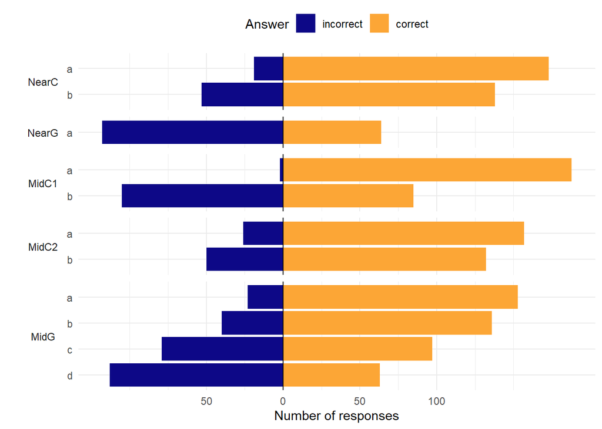

```r
# responses %>%
#   group_by(question_name, part) %>%
#   summarise(
#     n = n(),
#     num_correct = sum(fully_correct),
#     num_incorrect = sum(!fully_correct),
#     prop_correct = num_correct / n,
#     .groups = "drop"
#   ) %>%
#   pivot_longer(cols = starts_with("num_"), names_to = "type", values_to = "count", names_prefix = "num_") %>%
#   mutate(signed_count = if_else(type == "correct", count, -count)) %>%
#   mutate(question_name = fct_relevel(question_name, "NearC", "NearG", "MidC1", "MidC2", "MidG", "FarC1", "FarC2")) %>%
#   mutate(section = str_extract(question_name, "Near|Mid|Far") %>% fct_relevel("Near", "Mid", "Far")) %>%
#   mutate(q_part = fct_rev(paste0(str_extract(question_name, "G|C[:digit:]?"), letters[parse_number(part)]))) %>%
#   mutate(part = fct_rev(letters[parse_number(part)])) %>%
#   ggplot(aes(x = q_part, y = signed_count, fill = type)) +
#   geom_bar(position = "stack", stat = "identity") +
#   geom_hline(yintercept = 0) +
#   coord_flip() +
#   scale_y_continuous("Number of responses", labels = abs, breaks = seq(-50, 100, 50)) +
#   scale_fill_viridis_d("Answer", option = "plasma", end = 0.8, direction = -1, guide = guide_legend(reverse = TRUE)) +
#   facet_grid(rows = vars(section), scales = "free", space = "free", switch = "both") +
#   theme(
#     strip.placement = "outside",
#     strip.text.y.left = element_text(angle = 0),
#     legend.position = "top"
#   ) +
#   labs(x = "")

responses %>%
  group_by(question_name, part) %>%
  summarise(
    n = n(),
    num_correct = sum(fully_correct),
    num_incorrect = sum(!fully_correct),
    prop_correct = num_correct / n,
    .groups = "drop"
  ) %>%
  pivot_longer(cols = starts_with("num_"), names_to = "type", values_to = "count", names_prefix = "num_") %>%
  mutate(signed_count = if_else(type == "correct", count, -count)) %>%
  mutate(question_name = fct_relevel(question_name, "NearC", "NearG", "MidC1", "MidC2", "MidG", "FarC1", "FarC2")) %>%
  mutate(part = fct_rev(letters[parse_number(part)])) %>%
  ggplot(aes(x = part, y = signed_count, fill = type)) +
  geom_bar(position = "stack", stat = "identity") +
  geom_hline(yintercept = 0) +
  coord_flip() +
  scale_y_continuous("Number of responses", labels = abs, breaks = seq(-50, 100, 50)) +
  scale_fill_viridis_d("Answer", option = "plasma", end = 0.8, direction = -1, guide = guide_legend(reverse = TRUE)) +
  facet_grid(rows = vars(question_name), scales = "free", space = "free", switch = "both") +
  theme(
    strip.placement = "outside",
    strip.text.y.left = element_text(angle = 0),
    legend.position = "top"
  ) +
  labs(x = "")
```

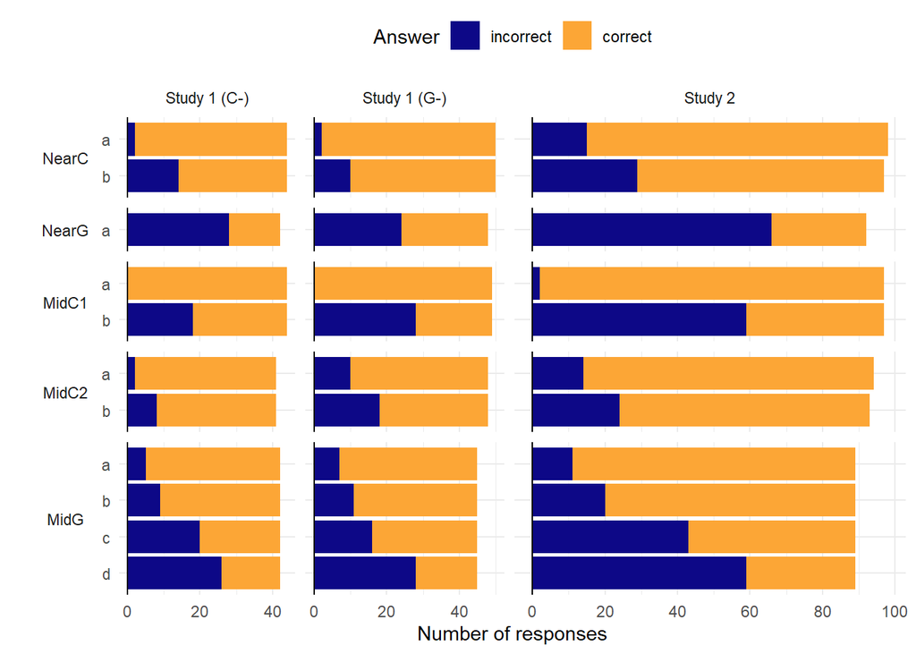

```r
responses %>%
  mutate(study_group = if_else(study == "study1", str_glue("Study 1 ({str_sub(group, start = 1, end = 1)}-)"), "Study 2")) %>%
  group_by(study_group, question_name, part) %>%
  summarise(
    n = n(),
    num_correct = sum(fully_correct),
    num_incorrect = sum(!fully_correct),
    prop_correct = num_correct / n,
    .groups = "drop"
  ) %>%
  pivot_longer(cols = starts_with("num_"), names_to = "type", values_to = "count", names_prefix = "num_") %>%
  mutate(signed_count = if_else(type == "correct", count, -count)) %>%
  mutate(question_name = fct_relevel(question_name, "NearC", "NearG", "MidC1", "MidC2", "MidG", "FarC1", "FarC2")) %>%
  mutate(part = fct_rev(letters[parse_number(part)])) %>%
  ggplot(aes(x = part, y = count, fill = type)) +
    geom_bar(position = "stack", stat = "identity") +
    geom_hline(yintercept = 0) +
    coord_flip() +
    #scale_y_continuous("Number of responses", labels = abs, breaks = seq(-50, 100, 50)) +
    scale_y_continuous("Number of responses", breaks = seq(0, 100, 20)) +
    scale_fill_viridis_d("Answer", option = "plasma", end = 0.8, direction = -1, guide = guide_legend(reverse = TRUE)) +
    facet_grid(cols = vars(study_group), rows = vars(question_name), scales = "free", space = "free", switch = "y") +
    theme(
      strip.placement = "outside",
      strip.text.y.left = element_text(angle = 0),
      legend.position = "top"
    ) +
    labs(x = "")
```

```r
ggsave("figs/FIG_study2_subsequent-task-scores.pdf", width = 15, height = 9, units = "cm")
```

```r
task_order_scores <- responses %>%
  select(study, task_order, username, question_name, q_type, marks_attained) %>%
  distinct() %>%
  group_by(study, task_order, username, q_type) %>%
  tally(marks_attained, name = "marks_attained") %>%
  pivot_wider(names_from = "q_type", values_from = "marks_attained", values_fill = 0)
```

There are several students who did not complete any of the relevant tasks, so they are not relevant to the question:

```r
participants %>%
  separate(username, into = c("study", "username"), sep = "_") %>%
  anti_join(task_order_data %>% select(study, username) %>% distinct(), by = c("study", "username")) %>%
  mutate(task_order = if_else(str_detect(group, "CG$"), "Classify first", "Generate first")) %>%
  janitor::tabyl(task_order) %>%
  basic_kable(caption = "Students who did not answer any of the Near or Mid tasks")
```

Students who did not answer any of the Near or Mid tasks

| task_order | n | percent |
| --- | --- | --- |
| Classify first | 60 | 0.5555556 |
| Generate first | 48 | 0.4444444 |

So we stick with just the 207 students who completed at least one of the Near/Mid tasks.

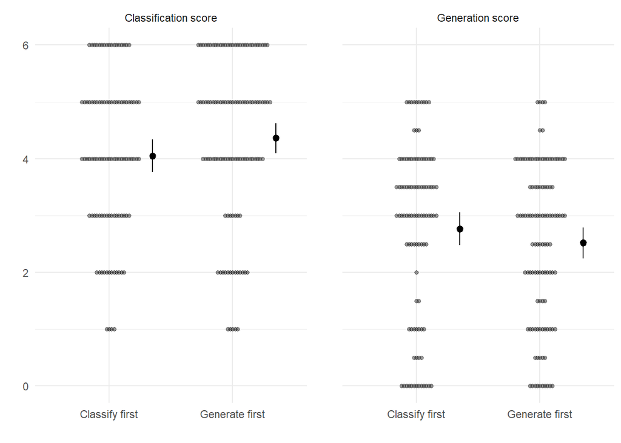

```r
task_order_model_C <- stan_glm(
    formula = C ~ 0 + task_order,
    data = task_order_scores,
    seed = 123,
    refresh = 0 # to prevent messages about the MCMC iterations being printed
  )
means_C <- modelbased::estimate_means(task_order_model_C, ci = ci_width, centrality = "median", ci_method = "hdi")
contrasts_C <- modelbased::estimate_contrasts(task_order_model_C, ci = ci_width, centrality = "median", ci_method = "hdi")

task_order_model_G <- stan_glm(
    formula = G ~ 0 + task_order,
    data = task_order_scores,
    seed = 123,
    refresh = 0 # to prevent messages about the MCMC iterations being printed
  )
means_G <- modelbased::estimate_means(task_order_model_G, ci = ci_width, centrality = "median", ci_method = "hdi")
contrasts_G <- modelbased::estimate_contrasts(task_order_model_G, ci = ci_width, centrality = "median", ci_method = "hdi")

means = bind_rows("C" = means_C, "G" = means_G, .id = "q_type")
contrasts = bind_rows("C" = contrasts_C, "G" = contrasts_G, .id = "q_type")

task_order_scores %>%
  pivot_longer(cols = c("G", "C"), names_to = "q_type", values_to = "marks_attained") %>%
  ggplot(aes(x = task_order, y = marks_attained)) +
  ggbeeswarm::geom_beeswarm(alpha = 0.4, stroke = 0) +
  geom_pointrange(data = means, aes(x = task_order, y = Mean, ymin = CI_low, ymax = CI_high),
                  position = position_nudge(x = 0.35),
                  size = 0.4) +
  facet_grid(cols = vars(q_type), labeller = labeller(q_type = c("C" = "Classification score", "G" = "Generation score"))) +
  labs(y = "", x = "") +
  theme(panel.spacing.x = unit(2, "lines"))
```

```r
ggsave("figs/FIG_studyX_task_order.pdf", width = 12, height = 7, units = "cm")
```

```r
task_order_means_table <- means %>%
  left_join(
    task_order_scores %>%
      pivot_longer(cols = c("G", "C"), names_to = "q_type", values_to = "marks_attained") %>%
      group_by(q_type, task_order) %>%
      summarise(
        N = n(),
        sd = sd(marks_attained),
        .groups = "drop"
      ),
    by = c("q_type", "task_order")
  ) %>%
  relocate(N, .before = Mean) %>%
  mutate(score = if_else(q_type == "C", "Classification", "Generation"), .before = 1, .keep = "unused") %>%
  mutate(estimate_hdi = str_glue("[{round(CI_low, 3)}, {round(CI_high, 3)}]"), .keep = "unused")

task_order_means_table %>%
  basic_kable(digits = 3) %>%
  collapse_rows(columns = 1, valign = "top")
```

| score | task_order | N | Mean | sd | estimate_hdi |
| --- | --- | --- | --- | --- | --- |
| Classification | Classify first | 98 | 4.049 | 1.410 | [3.764, 4.338] |
| Classification | Generate first | 109 | 4.361 | 1.476 | [4.092, 4.626] |
| Generation | Classify first | 98 | 2.761 | 1.567 | [2.479, 3.059] |
| Generation | Generate first | 109 | 2.519 | 1.401 | [2.248, 2.787] |

```r
task_order_means_table %>%
  basic_kable(digits = 3, format = "latex", booktabs = T) %>%
  cat()
```

```
\begin{table}
\centering
\begin{tabular}{llrrrl}
\toprule
score & task\_order & N & Mean & sd & estimate\_hdi\\
\midrule
Classification & Classify first & 98 & 4.049 & 1.410 & [3.764, 4.338]\\
Classification & Generate first & 109 & 4.361 & 1.476 & [4.092, 4.626]\\
Generation & Classify first & 98 & 2.761 & 1.567 & [2.479, 3.059]\\
Generation & Generate first & 109 & 2.519 & 1.401 & [2.248, 2.787]\\
\bottomrule
\end{tabular}
\end{table}
```

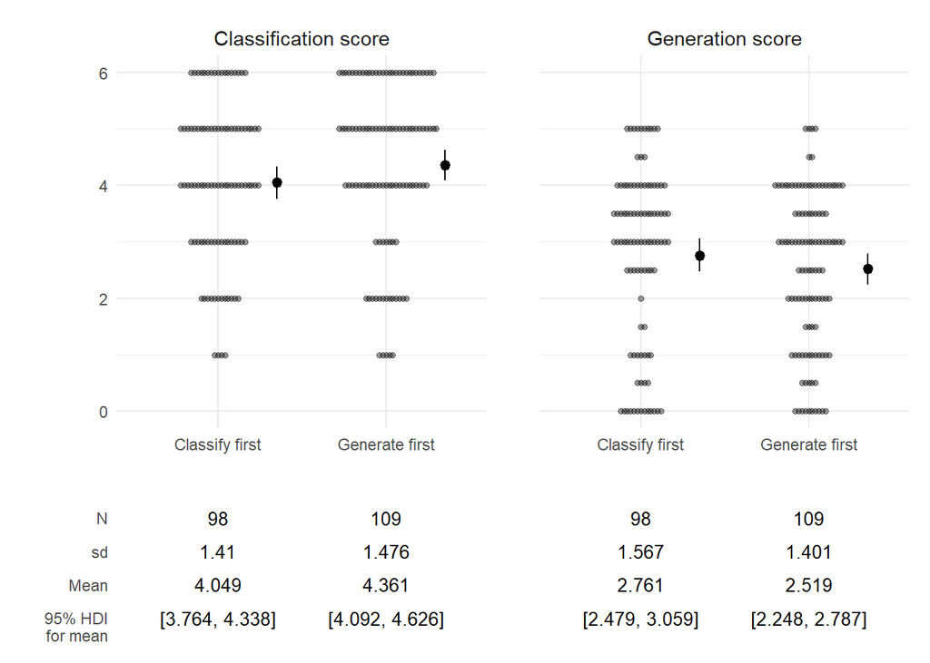

```r
# inspired by https://stackoverflow.com/questions/61977439/table-below-x-axis-in-ggplot
p1 <- task_order_scores %>%
  pivot_longer(cols = c("G", "C"), names_to = "q_type", values_to = "marks_attained") %>%
  ggplot(aes(x = task_order, y = marks_attained)) +
  ggbeeswarm::geom_beeswarm(alpha = 0.4, stroke = 0) +
  geom_pointrange(data = means, aes(x = task_order, y = Mean, ymin = CI_low, ymax = CI_high),
                  position = position_nudge(x = 0.35),
                  size = 0.4) +
  facet_grid(cols = vars(q_type), labeller = labeller(q_type = c("C" = "Classification score", "G" = "Generation score"))) +
  labs(y = "", x = "") +
  theme(panel.spacing.x = unit(2, "lines"), strip.text = element_text(size = 11))

p2 <- task_order_means_table %>%
  mutate(
    n = str_glue("{N}"),
    mean = str_glue("{round(Mean, digits = 3)}"),
    sd = str_glue("{round(sd, digits = 3)}")
  ) %>%
  pivot_longer(c(n, mean, sd, estimate_hdi), names_to = "layer", values_to = "label") %>%
  mutate(layer = fct_relevel(layer, c("n", "sd", "mean", "estimate_hdi")) %>% fct_rev()) %>%
  #filter(layer != "n") %>%
  ggplot(aes(x = task_order, y = layer, label = label)) +
  geom_text(size = 10 * 5/14) +
  labs(y = "", x = NULL) +
  scale_y_discrete(labels = c("n" = "N", "mean" = "Mean", "estimate_hdi" = "\n95% HDI\nfor mean")) +
  theme_minimal() +
  facet_grid(cols = vars(score), labeller = labeller(q_type = c("C" = "Classification score", "G" = "Generation score"))) +
  theme(axis.line = element_blank(), axis.ticks = element_blank(), axis.text.x = element_blank(),
        panel.grid = element_blank(), strip.text = element_blank(),
        panel.spacing.x = unit(2, "lines"))

p1 / p2 +  plot_layout(heights = c(8, 3))
```

```r
ggsave("figs/FIG_studyX_task_order_with_table.pdf", width = 15, height = 10, units = "cm")
```

```r
contrasts %>%
  basic_kable(digits = 3)
```

| q_type | Level1 | Level2 | Difference | CI_low | CI_high | pd | ROPE_Percentage | Std_Difference |
| --- | --- | --- | --- | --- | --- | --- | --- | --- |
| C | Classify first | Generate first | -0.312 | -0.718 | 0.061 | 0.942 | 0.124 | -0.215 |
| G | Classify first | Generate first | 0.237 | -0.126 | 0.660 | 0.886 | 0.209 | 0.160 |

# Interactions between tasks?

## NearG

> Give an example of a sequence which is increasing and bounded above.

There are a couple of hypotheses about students’ answers to this task, if they are being influenced by previous tasks:

1. students from study 1 G- groups will be more likely to use examples based on `1/2^n` than students from other groups, since they will have seen that as a worked solution to G1.
2. excluding the study1 G- groups, students in classify-first groups will be more likely to use `1/n`-based examples than those from generate-first groups, since they will have just seen `1/(an+b)` in NearC.

First we classify the type of response given by each student, blind to which group they are in:

```r
nearG_responses <- responses %>%
  select(-questionsummary) %>%
  filter(question_name == "NearG") %>%
  mutate(
    response_type = case_when(
      str_detect(response, "sqrt|u|log|sin|ln") ~ "other",
      # pick off some odd cases first
      str_trim(response) %in% c("(1/2*n)^(-1)") ~ "other",
      # identify use of example from G1
      str_detect(response, "/2\\^n|\\(1/2\\)\\^n") ~ "1/2^n",
      # pick off other uses of ^n
      str_detect(response, "\\^[-]?n|\\*\\*n") ~ "^n",
      # identify examples similar to NearC
      str_detect(response, "1/n(?!\\^)") ~ "1/n", # look ahead to rule out 1/n^2 etc
      str_detect(response, "[:digit:]/[:digit:]*[\\*]?n(?!\\^)") ~ "a/n",
      str_detect(response, "[:digit:]/\\([:digit:]*[\\*]?n\\)(?!\\^)") ~ "a/n",
      str_detect(response, "n/\\(n\\+1\\)|\\(n-1\\)/n") ~ "(expr in n)/(an+b)",
      str_detect(response, ".*n.*/\\([:digit:]*[\\*]*n[\\+-]*[:digit:]*\\)") ~ "(expr in n)/(an+b)",
      str_detect(response, "/\\([:digit:]*[\\*]*n[\\+-]*[:digit:]*\\)") ~ "1/(an+b)",
      str_detect(response, "/-n") ~ "1/n",
      # other stuff
      str_detect(response, "[:digit:]*[\\*]?n[:space:]*[\\+-][:space:]*[:digit:]*") ~ "an+b",
      str_detect(response, "[:digit:]+[\\*]?n|\\([-]?[:digit:]*\\)[\\*]?n") ~ "an+b",
      str_detect(response, "n\\^[:digit:]") ~ "n^2, n^3",
      str_trim(response) %in% c("n", "1+n", "n/2") ~ "an+b",
      str_detect(str_trim(response), "^[:digit:]+$") ~ "integer",
      TRUE ~ "other"
    ),
    response_type_overall = case_when(
      response_type %in% c("1/2^n") ~ "1/2^n",
      response_type %in% c("1/n", "a/n", "(expr in n)/(an+b)", "1/(an+b)") ~ "1/n",
      TRUE ~ "other"
    )
  )

nearG_responses %>%
  group_by(response_type_overall, response_type, response) %>%
  tally() %>%
  arrange(response_type_overall, response_type, -n, response) %>%
  basic_kable() %>%
  collapse_rows(columns = c(1:2), valign = "top")
```

| response_type_overall | response_type | response | n |
| --- | --- | --- | --- |
| 1/2^n | 1/2^n | 1-1/2^n | 9 |
| 1/2^n | 1/2^n | 1-(1/2)^n | 3 |
| 1/2^n | 1/2^n | 1/2^n | 3 |
| 1/2^n | 1/2^n | -1/2^n | 2 |
| 1/2^n | 1/2^n | -1-1/2^n | 1 |
| 1/2^n | 1/2^n | 1-(1/2^n) | 1 |
| 1/2^n | 1/2^n | 1+1/2^n | 1 |
| 1/2^n | 1/2^n | 11/2^n | 1 |
| 1/2^n | 1/2^n | 257/16-1/2^n | 1 |
| 1/2^n | 1/2^n | 5-(1/2^n) | 1 |
| 1/2^n | 1/2^n | 5-1/2^n | 1 |
| 1/2^n | 1/2^n | n -1/2^n | 1 |
| 1/n | (expr in n)/(an+b) | (n-1)/n | 2 |
| 1/n | (expr in n)/(an+b) | n/(n+1) | 2 |
| 1/n | (expr in n)/(an+b) | (2*n+3)/(n+1) | 1 |
| 1/n | (expr in n)/(an+b) | n/(n+1) | 1 |
| 1/n | (expr in n)/(an+b) | n/(n+2) | 1 |
| 1/n | 1/(an+b) | 1/(2*n+4) | 1 |
| 1/n | 1/(an+b) | 1/(4*n+4) | 1 |
| 1/n | 1/(an+b) | 1/(n-1) | 1 |
| 1/n | 1/n | -1/n | 13 |
| 1/n | 1/n | 1-1/n | 8 |
| 1/n | 1/n | 1/n | 5 |
| 1/n | 1/n | 1/-n | 2 |
| 1/n | 1/n | 5-1/n | 2 |
| 1/n | 1/n | 0-1/n | 1 |
| 1/n | 1/n | 1/-n+5 | 1 |
| 1/n | 1/n | 1/(1+1/n) | 1 |
| 1/n | 1/n | 1/n+9 | 1 |
| 1/n | 1/n | 10-1/n | 1 |

[output cut: 73 more lines]

```r
nearG_responses %>%
  write_csv("data-clean/studyX_NearG_responses.csv")
```

```r
nearG_responses %>%
  group_by(response_type_overall, response_type) %>%
  tally() %>%
  arrange(response_type_overall, -n) %>%
  basic_kable() %>%
  collapse_rows(columns = c(1), valign = "top")
```

| response_type_overall | response_type | n |
| --- | --- | --- |
| 1/2^n | 1/2^n | 25 |
| 1/n | 1/n | 39 |
| 1/n | a/n | 11 |
| 1/n | (expr in n)/(an+b) | 7 |
| 1/n | 1/(an+b) | 3 |
| other | other | 28 |
| other | an+b | 24 |
| other | ^n | 17 |
| other | integer | 16 |
| other | n^2, n^3 | 12 |

Now to check the hypotheses:

> 1. students from study 1 G- groups will be more likely to use examples based on `1/2^n` than students from other groups, since they will have seen that as a worked solution to G1.

```r
nearG_H1 <- nearG_responses %>%
  mutate(big_group = if_else(study == "study1" & str_detect(group, "^G"), "Study 1 G-", "Other")) %>%
  select(big_group, response_type_overall) %>%
  janitor::tabyl(big_group, response_type_overall) %>%
  janitor::adorn_totals(where = "col")

nearG_H1 %>%
  basic_kable()
```

| big_group | 1/2^n | 1/n | other | Total |
| --- | --- | --- | --- | --- |
| Other | 8 | 47 | 79 | 134 |
| Study 1 G- | 17 | 13 | 18 | 48 |

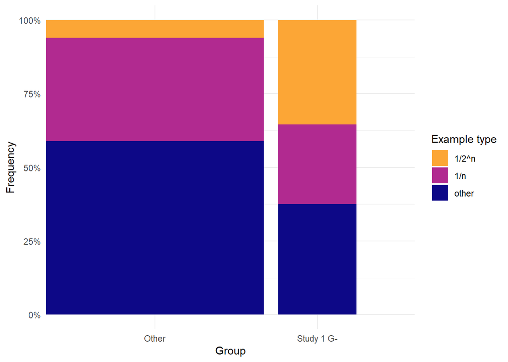

```r
nearG_H1 %>%
  pivot_longer(cols = !c(big_group, Total), names_to = "example_type", values_to = "frequency") %>%
  ggplot(aes(x = big_group, y = frequency, fill = example_type, width = Total/100)) +
  geom_bar(position = "fill", stat = "identity") +
  scale_fill_viridis_d("Example type", option = "plasma", end = 0.8, direction = -1) +
  scale_y_continuous(labels = scales::percent) +
  labs(x = "Group", y = "Frequency")
```

This suggests that it is indeed the case that the Study 1 G- groups are more likely to use `1/2^n`-based examples.

> 2. excluding the study1 G- groups, students in classify-first groups will be more likely to use `1/n`-based examples than those from generate-first groups, since they will have just seen `1/(an+b)` in NearC.

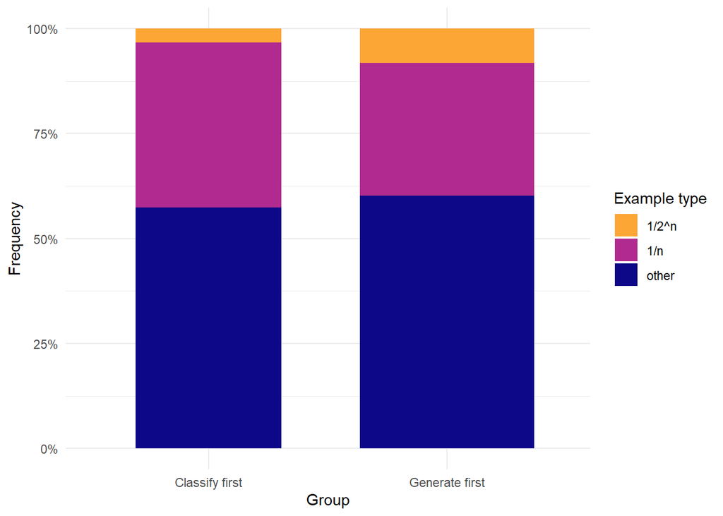

```r
nearG_H2 <- nearG_responses %>%
  filter(!(study == "study1" & str_detect(group, "^G"))) %>%
  mutate(big_group = if_else(str_detect(group, "G$"), "Classify first", "Generate first")) %>%
  select(big_group, response_type_overall) %>%
  janitor::tabyl(big_group, response_type_overall) %>%
  janitor::adorn_totals(where = "col")

nearG_H2 %>%
  pivot_longer(cols = !c(big_group, Total), names_to = "example_type", values_to = "frequency") %>%
  ggplot(aes(x = big_group, y = frequency, fill = example_type, width = Total/100)) +
  geom_bar(position = "fill", stat = "identity") +
  scale_fill_viridis_d("Example type", option = "plasma", end = 0.8, direction = -1) +
  scale_y_continuous(labels = scales::percent) +
  labs(x = "Group", y = "Frequency")
```

```r
nearG_H2 %>%
  basic_kable()
```

| big_group | 1/2^n | 1/n | other | Total |
| --- | --- | --- | --- | --- |
| Classify first | 2 | 24 | 35 | 61 |
| Generate first | 6 | 23 | 44 | 73 |

While the proportion is definitely higher, it’s not significantly so:

```r
prop.test(nearG_H2$`1/n`, nearG_H2$`Total`, alternative = "greater")
```

```
##
##  2-sample test for equality of proportions with continuity correction
##
## data:  nearG_H2$`1/n` out of nearG_H2$Total
## X-squared = 0.58524, df = 1, p-value = 0.2221
## alternative hypothesis: greater
## 95 percent confidence interval:
##  -0.07299039  1.00000000
## sample estimates:
##    prop 1    prop 2
## 0.3934426 0.3150685
```

One table and plot for both together:

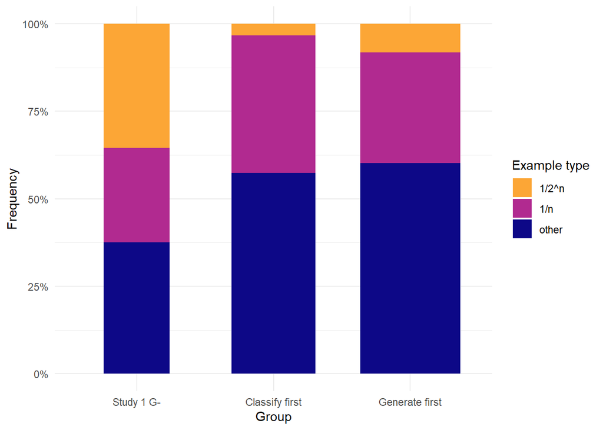

```r
nearG_Hs <- nearG_responses %>%
  mutate(big_group = case_when(
    study == "study1" & str_detect(group, "^G") ~ "Study 1 G-",
    str_detect(group, "G$") ~ "Classify first",
    TRUE ~ "Generate first"
  )) %>%
  mutate(big_group = fct_relevel(big_group, "Study 1 G-")) %>% # move that group first
  select(big_group, response_type_overall) %>%
  janitor::tabyl(big_group, response_type_overall) %>%
  janitor::adorn_totals(where = "col")

nearG_Hs %>%
  pivot_longer(cols = !c(big_group, Total), names_to = "example_type", values_to = "frequency") %>%
  ggplot(aes(x = big_group, y = frequency, fill = example_type, width = Total/100)) +
  geom_bar(position = "fill", stat = "identity") +
  scale_fill_viridis_d("Example type", option = "plasma", end = 0.8, direction = -1) +
  scale_y_continuous(labels = scales::percent) +
  labs(x = "Group", y = "Frequency")
```

```r
nearG_Hs %>%
  janitor::adorn_percentages(,,!c(Total, big_group)) %>%
  janitor::adorn_pct_formatting(digits = 0,,,!c(Total, big_group)) %>%
  janitor::adorn_ns(position = "front",,,!c(Total, big_group)) %>%
  rename(Group = big_group) %>%
  relocate(N = Total, .after = Group) %>%
  basic_kable() %>%
  add_header_above(c(" " = 2, "Example type" = 3))
```

| Group | N | Example type 1/2^n | Example type 1/n | Example type other |
| --- | --- | --- | --- | --- |
| Study 1 G- | 48 | 17 (35%) | 13 (27%) | 18 (38%) |
| Classify first | 61 | 2 (3%) | 24 (39%) | 35 (57%) |
| Generate first | 73 | 6 (8%) | 23 (32%) | 44 (60%) |

```r
nearG_Hs %>%
  janitor::adorn_percentages(,,!c(Total, big_group)) %>%
  janitor::adorn_pct_formatting(digits = 0,,,!c(Total, big_group)) %>%
  janitor::adorn_ns(position = "front",,,!c(Total, big_group)) %>%
  rename(Group = big_group) %>%
  relocate(N = Total, .after = Group) %>%
  basic_kable(format = "latex", booktabs = T) %>%
  add_header_above(c(" " = 2, "Example type" = 3)) %>%
  cat()
```

```
\begin{table}
\centering
\begin{tabular}{lrlll}
\toprule
\multicolumn{2}{c}{ } & \multicolumn{3}{c}{Example type} \\
\cmidrule(l{3pt}r{3pt}){3-5}
Group & N & 1/2\textasciicircum{}n & 1/n & other\\
\midrule
Study 1 G- & 48 & 17 (35\%) & 13 (27\%) & 18 (38\%)\\
Classify first & 61 & 2  (3\%) & 24 (39\%) & 35 (57\%)\\
Generate first & 73 & 6  (8\%) & 23 (32\%) & 44 (60\%)\\
\bottomrule
\end{tabular}
\end{table}
```

## MidG

> In each case below, give an example of an arithmetic sequence with the stated property, by entering an expression for the general term. If it is not possible, enter `none`. (a) Increasing (b) Decreasing (c) Bounded above (d) Decreasing and bounded below

First we classify the type of response given by each student, blind to which group they are in:

```r
midG_responses <- responses %>%
  select(-questionsummary) %>%
  filter(question_name == "MidG") %>%
  mutate(
    response_type = case_when(
      str_trim(response) %in% c("none") ~ "none",
      str_detect(response, "sqrt|u|log|sin|ln|abs") ~ "other",
      # pick off some odd cases first
      str_trim(response) %in% c("(1/2*n)^(-1)") ~ "other",
      # identify use of example from G1
      str_detect(response, "/2\\^n|\\(1/2\\)\\^n") ~ "1/2^n",
      str_detect(response, "2\\^\\(n-1\\)") ~ "1/2^n",
      str_detect(response, "1/\\(2\\^n\\)") ~ "1/2^n",
      # pick off other uses of ^n
      str_detect(response, "\\^[-]?n|\\*\\*n") ~ "^n",
      str_detect(response, "n\\^[:digit:]") ~ "n^2, n^3",
      # identify examples similar to NearC
      str_detect(response, "1/n(?!\\^)") ~ "1/n", # look ahead to rule out 1/n^2 etc
      str_detect(response, "[:digit:]/[:digit:]*[\\*]?n(?!\\^)") ~ "a/n",
      str_detect(response, "[:digit:]/\\([:digit:]*[\\*]?n\\)(?!\\^)") ~ "a/n",
      str_detect(response, "n/\\(n\\+1\\)|\\(n-1\\)/n") ~ "(expr in n)/(an+b)",
      str_detect(response, ".*n.*/\\([:digit:]*[\\*]*n[\\+-]*[:digit:]*\\)") ~ "(expr in n)/(an+b)",
      str_detect(response, "/\\([:digit:]*[\\*]*n[\\+-]*[:digit:]*\\)") ~ "1/(an+b)",
      str_detect(response, "/-n") ~ "1/n",
      # other stuff
      str_detect(response, "[:digit:]*[\\*]?n[:space:]*[\\+-][:space:]*[:digit:]*") ~ "an+b",
      str_detect(response, "[-]?[:digit:]*[:space:]*[\\+-][:space:]*[:digit:]*[\\*]?n") ~ "an+b",
      str_detect(response, "[:digit:]+[\\*]?n|\\([-]?[:digit:]*\\)[\\*]?n") ~ "an+b",
      str_trim(response) %in% c("n", "1+n", "n/2", "2-(n)", "ln(2)-ln(2)*(n-1)", "n/2+1", "n*d") ~ "an+b",
      str_detect(str_trim(response), "^[:digit:]+$") ~ "integer",
      TRUE ~ "other"
    ),
    response_type_overall = case_when(
      response_type %in% c("1/2^n") ~ "1/2^n",
      response_type %in% c("1/n", "a/n", "(expr in n)/(an+b)", "1/(an+b)") ~ "1/n",
      response_type %in% c("an+b") ~ "an+b",
      response_type %in% c("none") ~ "none",
      TRUE ~ "other"
    )
  )

midG_responses %>%
  group_by(response_type_overall, response_type, response) %>%
  tally() %>%
  arrange(response_type_overall, response_type, -n, response) %>%
  basic_kable() %>%
  collapse_rows(columns = c(1:2), valign = "top")
```

| response_type_overall | response_type | response | n |
| --- | --- | --- | --- |
| 1/2^n | 1/2^n | 1-1/2^n | 4 |
| 1/2^n | 1/2^n | 1/2^n | 4 |
| 1/2^n | 1/2^n | -1/2^n | 2 |
| 1/2^n | 1/2^n | 1+1/2^n | 2 |
| 1/2^n | 1/2^n | 1-1/(2^n) | 1 |
| 1/2^n | 1/2^n | 1-1/2^(n-1) | 1 |
| 1/2^n | 1/2^n | 1 - 1/(2^(n-1)) | 1 |
| 1/2^n | 1/2^n | 1/(2^n) | 1 |
| 1/2^n | 1/2^n | 1/2^(n-1) | 1 |
| 1/2^n | 1/2^n | 1/2^n+15/16 | 1 |
| 1/2^n | 1/2^n | 1+1/2^(n-1) | 1 |
| 1/2^n | 1/2^n | 5-(1/2^(n-1)) | 1 |
| 1/2^n | 1/2^n | 7-1/2^n | 1 |
| 1/n | (expr in n)/(an+b) | n/(n+1) | 1 |
| 1/n | 1/(an+b) | -1/(n-1)+1 | 1 |
| 1/n | 1/(an+b) | 1/(2*n+3) | 1 |
| 1/n | 1/(an+b) | 1/(n-1)+1 | 1 |
| 1/n | 1/(an+b) | 1/3-(1/(n-1)) | 1 |
| 1/n | 1/n | 1/n | 21 |
| 1/n | 1/n | 1-1/n | 4 |
| 1/n | 1/n | -1/n | 2 |
| 1/n | 1/n | -1+8*(1/n-1) | 1 |
| 1/n | 1/n | 1- 1/n | 1 |
| 1/n | 1/n | 1-1/n(n-1) | 1 |
| 1/n | 1/n | 1-2(1/n) | 1 |
| 1/n | 1/n | 1-2*(1/n) | 1 |
| 1/n | 1/n | 1/n-1 | 1 |
| 1/n | 1/n | 1/n-2 | 1 |
| 1/n | 1/n | 1+1/n | 1 |
| 1/n | 1/n | 2-1/n | 1 |

[output cut: 277 more lines]

```r
midG_responses %>%
  write_csv("data-clean/studyX_MidG_responses.csv")
```

```r
nearG_Hs <- midG_responses %>%
  mutate(big_group = case_when(
    study == "study1" & str_detect(group, "^G") ~ "Study 1 G-",
    str_detect(group, "G$") ~ "Classify first",
    TRUE ~ "Generate first"
  )) %>%
  select(big_group, response_type_overall) %>%
  janitor::tabyl(big_group, response_type_overall) %>%
  janitor::adorn_totals(where = "col")

nearG_Hs %>%
  basic_kable()
```

| big_group | 1/2^n | 1/n | an+b | none | other | Total |
| --- | --- | --- | --- | --- | --- | --- |
| Classify first | 7 | 14 | 178 | 16 | 25 | 240 |
| Generate first | 9 | 24 | 150 | 53 | 48 | 284 |
| Study 1 G- | 5 | 15 | 107 | 25 | 28 | 180 |

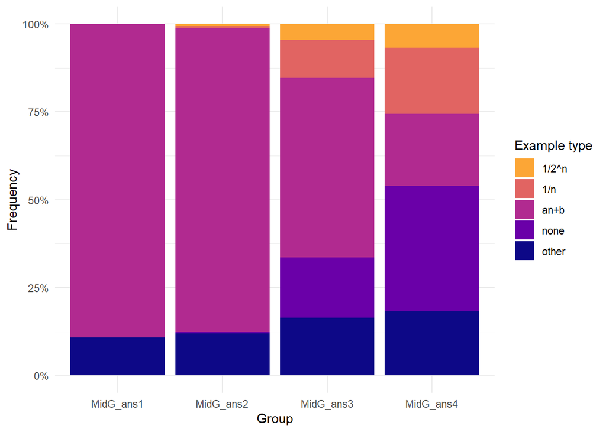

```r
midG_responses %>%
  select(q_part, response_type_overall) %>%
  janitor::tabyl(q_part, response_type_overall) %>%
  janitor::adorn_totals(where = "col") %>%
  pivot_longer(cols = !c(q_part, Total), names_to = "example_type", values_to = "frequency") %>%
  ggplot(aes(x = q_part, y = frequency, fill = example_type)) +
  geom_bar(position = "fill", stat = "identity") +
  scale_fill_viridis_d("Example type", option = "plasma", end = 0.8, direction = -1) +
  scale_y_continuous(labels = scales::percent) +
  labs(x = "Group", y = "Frequency")
```

How does MidC1 influence answers? It was randomised, so different students will have had examples of different types to classify:

```r
MidC1_examples <- responses %>%
  filter(question_name == "MidC1") %>%
  select(study, group, username, questionsummary) %>%
  distinct() %>%
  separate(questionsummary, into = c("MidC1_example", "ans"), sep = " is ") %>%
  mutate(MidC1_example = str_remove_all(MidC1_example, "\\\\|\\(|\\)|,|\\{|\\}"))

head(MidC1_examples, n = 10) %>%
  basic_kable()
```

| study | group | username | MidC1_example | ans |
| --- | --- | --- | --- | --- |
| study1 | GCG | anon100 | 5-3n | Decreasing and Bounded above |
| study1 | CGC | anon101 | 5-3n | Decreasing and Bounded above |
| study1 | CGC | anon103 | 5-2n | Decreasing and Bounded above |
| study1 | CGC | anon104 | 9-5n | Decreasing and Bounded above |
| study1 | GGC | anon105 | 8-5n | Decreasing and Bounded above |
| study1 | GGC | anon106 | 9-5n | Decreasing and Bounded above |
| study1 | GCG | anon109 | 5-2n | Decreasing and Bounded above |
| study1 | CCG | anon110 | 3n-1 | Increasing and Bounded below |
| study1 | CCG | anon112 | 4n-2 | Increasing and Bounded below |
| study1 | CGC | anon113 | 3n-1 | Increasing and Bounded below |

The different examples used in MidC1 will be relevant to different parts of MidG:

| MidC1 example | Gives answer to MidG |
| --- | --- |
| Decreasing and Bounded above | b, c |
| Increasing and Bounded below | a |

Do students make use of these examples? If so, then we’d expect to see a difference in performance on the relevant parts of MidG, based on the type of example seen in MidC1:

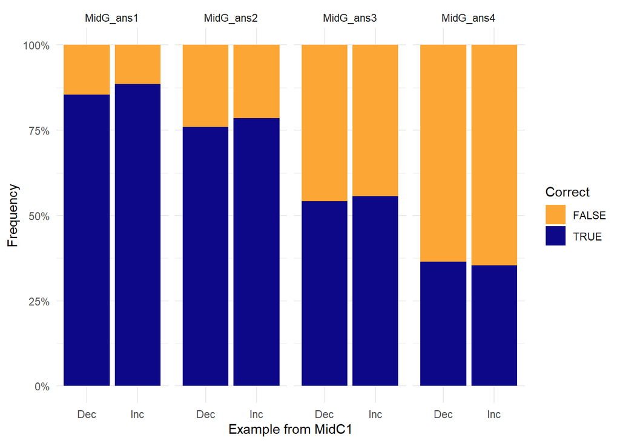

```r
midG_responses %>%
  left_join(MidC1_examples, by = c("study", "group", "username")) %>%
  select(q_part, response, fully_correct, MidC1_example, ans) %>%
  mutate(ans = str_sub(ans, start = 1, end = 3)) %>%
  group_by(q_part, ans, fully_correct) %>%
  tally() %>%
  filter(!is.na(ans)) %>%
  ggplot(aes(x = ans, y = n, fill = fully_correct)) +
  geom_bar(position = "fill", stat = "identity") +
  scale_fill_viridis_d("Correct", option = "plasma", end = 0.8, direction = -1) +
  scale_y_continuous(labels = scales::percent) +
  labs(x = "Example from MidC1", y = "Frequency") +
  facet_grid(cols = vars(q_part))
```

There appears to be no difference.

Perhaps it is restricted to just the students in the classify-first group?

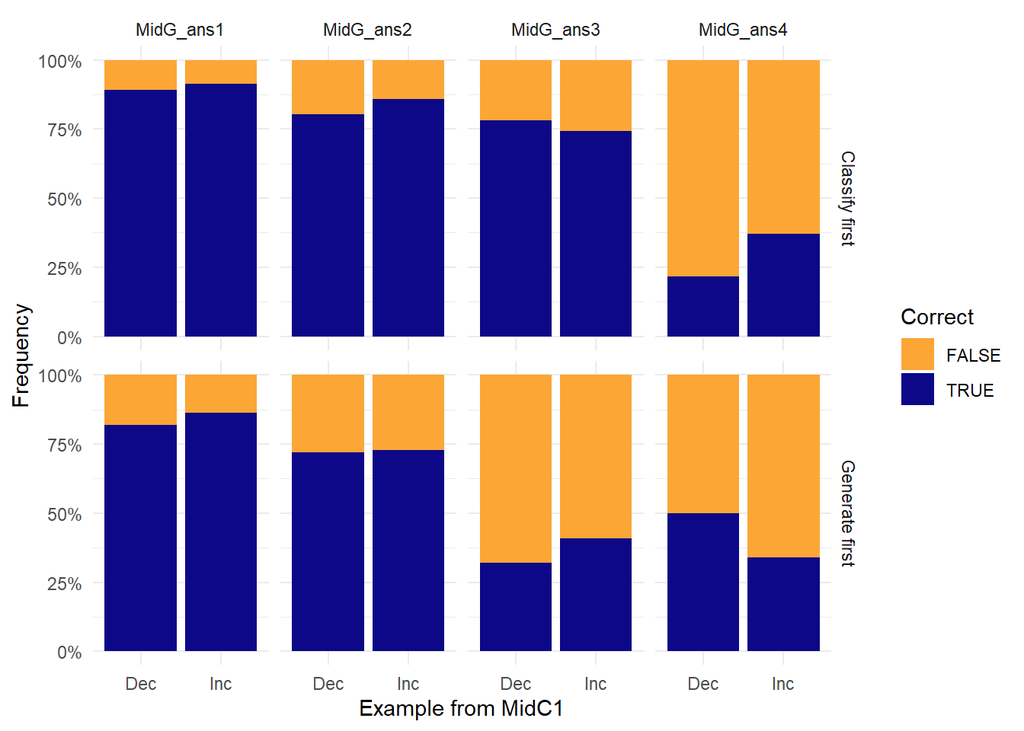

```r
midG_responses %>%
  left_join(MidC1_examples, by = c("study", "group", "username")) %>%
  select(study, group, q_part, response, fully_correct, MidC1_example, ans) %>%
  mutate(study_group = if_else(str_detect(group, "G$"), "Classify first", "Generate first")) %>%
  mutate(ans = str_sub(ans, start = 1, end = 3)) %>%
  group_by(study_group, q_part, ans, fully_correct) %>%
  tally() %>%
  filter(!is.na(ans)) %>%
  ggplot(aes(x = ans, y = n, fill = fully_correct)) +
  geom_bar(position = "fill", stat = "identity") +
  scale_fill_viridis_d("Correct", option = "plasma", end = 0.8, direction = -1) +
  scale_y_continuous(labels = scales::percent) +
  labs(x = "Example from MidC1", y = "Frequency") +
  facet_grid(cols = vars(q_part), rows = vars(study_group))
```

Even here, there is no apparent difference.

Looking at the actual content of the responses:

```r
midGandC <- midG_responses %>%
  left_join(MidC1_examples, by = c("study", "group", "username")) %>%
  select(study, group, username, q_part, fully_correct, response_type, response_type_overall, response, MidC1_example, MidC1_type = ans)
```

```r
midGandC %>%
  filter(q_part %in% c("MidG_ans1", "MidG_ans2", "MidG_ans3")) %>%
  janitor::tabyl(q_part) %>%
  janitor::adorn_totals(where = "row") %>%
  select(-percent) %>%
  basic_kable(caption = "Responses to relevant MidG tasks")
```

Responses to relevant MidG tasks

| q_part | n |
| --- | --- |
| MidG_ans1 | 176 |
| MidG_ans2 | 176 |
| MidG_ans3 | 176 |
| Total | 528 |

### Increasing and Bounded below

These examples from MidC1 are of exactly the right type for MidG_ans1. How often do students quote that example?

```r
midGandC %>%
  filter(q_part == "MidG_ans1") %>%
  filter(MidC1_type == "Increasing and Bounded below") %>%
  select(study, group, username, response, MidC1_example) %>%
  # Use the Ryacas computer algebra system to compare the two answers
  # To prepare, need to add implied multiplication to the expressions
  mutate(
    response = str_replace(response, "2u_n", "2*u_n"),
    response = str_replace(response, "\\)(?=[:digit:])", "\\)\\*"),
    response = str_replace(response, "(?<=[:digit:])\\(", "\\*\\("),
    response = str_replace(response, "(?<=[:digit:])n", "\\*n"),
    diff = paste0(response, "-(", str_replace(MidC1_example, "(?<=[:digit:])n", "\\*n"), ")")
  ) %>%
  mutate(
    response_diff = map_chr(diff, ~ .x %>% Ryacas::y_fn("Simplify") %>% Ryacas::yac_str()),
    .keep = "unused"
  ) %>%
  arrange(response_diff) %>%
  basic_kable()
```

| study | group | username | response | MidC1_example | response_diff |
| --- | --- | --- | --- | --- | --- |
| study2 | GC | anon101 | 1+3*(n-1) | 4n-1 | -(n+1) |
| study2 | GC | anon136 | 2+(n-1)*2 | 3n+1 | -(n+1) |
| study2 | CG | anon18 | 2*(n-1) | 3n-1 | -(n+1) |
| study2 | GC | anon203 | n+1 | 2n+2 | -(n+1) |
| study1 | GGC | anon114 | 1 + 2*(n-1) | 3n+1 | -(n+2) |
| study1 | GGC | anon190 | 1+2*(n-1) | 3n+1 | -(n+2) |
| study2 | GC | anon121 | 1+(n-1)*2 | 3n+1 | -(n+2) |
| study1 | CGC | anon113 | 1+(n-1)*3 | 3n-1 | -1 |
| study2 | GC | anon135 | 2+(n-1)*4 | 4n-1 | -1 |
| study1 | GGC | anon147 | 2+5*(n-1) | 5n-1 | -2 |
| study1 | CCG | anon50 | 2*n | 2n+2 | -2 |
| study1 | GCG | anon151 | 1+2*(n-1) | 2n+2 | -3 |
| study2 | GC | anon115 | 2*(n-1) | 4n-2 | (-2)*n |
| study2 | GC | anon138 | n+1 | 3n+1 | (-2)*n |
| study2 | GC | anon24 | n | 3n+1 | (-2)*n-1 |
| study1 | GGC | anon153 | n+2 | 3n+1 | (-2)*n+1 |
| study1 | GCG | anon54 | n | 3n-1 | (-2)*n+1 |
| study1 | GGC | anon64 | 1+3*(n-1) | 5n-3 | (-2)*n+1 |
| study1 | CCG | anon65 | 2 + n | 3n+1 | (-2)*n+1 |
| study2 | CG | anon192 | n | 3n-1 | (-2)*n+1 |
| study2 | CG | anon97 | n+2 | 3n+1 | (-2)*n+1 |
| study1 | GGC | anon227 | 2+2*n | 4n-1 | (-2)*n+3 |
| study2 | GC | anon160 | 1+2*n | 4n-2 | (-2)*n+3 |
| study2 | CG | anon214 | n+2 | 3n-1 | (-2)*n+3 |
| study2 | GC | anon63 | 1+2*n | 4n-2 | (-2)*n+3 |
| study1 | GGC | anon70 | 1 | 3n+1 | (-3)*n |
| study2 | GC | anon13 | 1 | 3n+1 | (-3)*n |
| study1 | CGC | anon125 | 2+(n-1)*2 | 5n-1 | (-3)*n+1 |
| study1 | GCG | anon160 | n | 4n-1 | (-3)*n+1 |
| study1 | CGC | anon45 | 2*(n-1) | 5n-3 | (-3)*n+1 |
| study2 | GC | anon166 | 1+(n-1)*2 | 5n-2 | (-3)*n+1 |
| study2 | CG | anon96 | n | 4n-1 | (-3)*n+1 |
| study1 | GGC | anon152 | n | 4n-2 | (-3)*n+2 |
| study1 | GGC | anon164 | 2+1*(n-1) | 4n-1 | (-3)*n+2 |
| study1 | CGC | anon48 | 1+2*(n-1) | 5n-3 | (-3)*n+2 |
| study1 | CGC | anon117 | n+3 | 4n-2 | (-3)*n+5 |
| study1 | CGC | anon74 | (n-1) | 5n-1 | (-4)*n |
| study1 | GCG | anon12 | n | 5n-1 | (-4)*n+1 |
| study1 | CCG | anon175 | n | 5n-1 | (-4)*n+1 |
| study2 | CG | anon78 | n | 5n-1 | (-4)*n+1 |
| study1 | CGC | anon14 | n+1 | 5n-2 | (-4)*n+3 |
| study1 | CGC | anon42 | n | 5n-3 | (-4)*n+3 |
| study2 | CG | anon153 | n+1 | 5n-2 | (-4)*n+3 |
| study2 | GC | anon28 | 1+ (n-1) | 5n-3 | (-4)*n+3 |
| study2 | GC | anon202 | 5 | 5n-1 | (-5)*n+6 |
| study2 | CG | anon197 | 7 | 5n-2 | (-5)*n+9 |
| study2 | CG | anon143 | 3*n-1 | 3n-1 | 0 |
| study2 | CG | anon215 | 2*n+2 | 2n+2 | 0 |
| study2 | CG | anon204 | 2*n | 3n-1 | 1-n |
| study2 | GC | anon60 | 2*n | 3n-1 | 1-n |
| study1 | CCG | anon110 | 3*n+1 | 3n-1 | 2 |
| study2 | CG | anon177 | 3*n+1 | 3n-1 | 2 |
| study2 | CG | anon26 | 4*n | 4n-2 | 2 |
| study1 | CCG | anon211 | 3*n+1 | 4n-1 | 2-n |
| study1 | GCG | anon162 | 1+(n-1) | 5n-2 | 2*((-2)*n+1) |
| study1 | GCG | anon73 | n+1 | 5n-1 | 2*((-2)*n+1) |
| study2 | CG | anon108 | n-1 | 5n-3 | 2*((-2)*n+1) |
| study2 | CG | anon33 | n | 5n-2 | 2*((-2)*n+1) |
| study2 | GC | anon57 | n | 5n-2 | 2*((-2)*n+1) |
| study1 | GCG | anon154 | n+1 | 3n-1 | 2*(1-n) |
| study1 | GGC | anon161 | 2*n | 4n-2 | 2*(1-n) |
| study1 | CCG | anon182 | n+1 | 3n-1 | 2*(1-n) |
| study1 | GGC | anon19 | 3*n | 5n-2 | 2*(1-n) |
| study1 | CGC | anon82 | 2+2*(n-1) | 4n-2 | 2*(1-n) |
| study2 | GC | anon195 | 5+3*(n-1) | 5n-2 | 2*(2-n) |
| study1 | CGC | anon16 | 3+5*(n-1) | 3n+1 | 2*n-3 |
| study1 | CCG | anon112 | 2*u_n+1 | 4n-2 | 2*u _n+(-4)*n+3 |
| study2 | CG | anon12 | 5+3*(n-1) | 4n-1 | 3-n |
| study2 | CG | anon61 | 2*n+2 | 3n-1 | 3-n |
| study2 | GC | anon110 | 2 +(n-1) | 4n-2 | 3*(1-n) |
| study2 | CG | anon184 | n+1 | 4n-2 | 3*(1-n) |
| study2 | GC | anon205 | 3*u | 5n-2 | 3*u+(-5)*n+2 |
| study1 | CGC | anon221 | 3 | 4n-1 | 4*(1-n) |
| study2 | CG | anon31 | 4*x+5 | 5n-3 | 4*x+(-5)*n+8 |
| study2 | GC | anon67 | -1+8*(n-1) | 3n+1 | 5*(n-2) |
| study1 | GGC | anon92 | a+3*(n-1) | 5n-1 | a+(-2)*n-2 |
| study2 | CG | anon122 | 3*n+1 | 2n+2 | n-1 |
| study2 | GC | anon41 | 1+(n-1)*3 | 2n+2 | n-4 |
| study1 | CCG | anon171 | 5+5*(n-1) | 4n-1 | n+1 |

Not often at all! There are only a couple of cases of students using the identical answer (`3*n-1` and `2*n+2`), both of whom are in the study2 CG group. There are a few more cases where the answer differs only by a constant (e.g. `3n-1` becomes `3*n+1`). But overall the examples seem to be quite unrelated to MidC1.

### Decreasing and Bounded above

These examples from MidC1 are of exactly the right type for MidG_ans2 and MidG_ans3. How often do students quote that example?

```r
midGandC %>%
  filter(q_part %in% c("MidG_ans2", "MidG_ans3")) %>%
  filter(MidC1_type == "Decreasing and Bounded above") %>%
  select(study, group, username, q_part, response, MidC1_example) %>%
  # Use the Ryacas computer algebra system to compare the two answers
  # To prepare, need to add implied multiplication to the expressions
  mutate(
    response_raw = response,
    response = str_replace(response, "2u_n", "2*u_n"),
    response = str_replace(response, "\\)(?=[:digit:])", "\\)\\*"),
    response = str_replace(response, "(?<=[:digit:])\\(", "\\*\\("),
    response = str_replace(response, "(?<=[:digit:])n", "\\*n"),
    response = str_replace(response, "none", "0"),
    response = str_replace(response, "\\[8,6,4,2\\]", "0"),
    response = str_replace(response, "u_\\(n-1\\)", "un"),
    response = str_replace(response, "\\)\\(", "\\)\\*\\("),
    diff = paste0(response, "-(", str_replace(MidC1_example, "(?<=[:digit:])n", "\\*n"), ")")
  ) %>% mutate(
    response_diff = map_chr(diff, ~ .x %>% Ryacas::y_fn("Simplify") %>% Ryacas::yac_str()),
    .keep = "unused"
  ) %>%
  select(-response) %>%
  arrange(response_diff) %>%
  basic_kable()
```

| study | group | username | q_part | MidC1_example | response_raw | response_diff |
| --- | --- | --- | --- | --- | --- | --- |
| study2 | CG | anon208 | MidG_ans2 | 5-2n | 4-3*n | -(n+1) |
| study1 | CGC | anon128 | MidG_ans2 | 7-4n | 4-5*n | -(n+3) |
| study2 | CG | anon114 | MidG_ans2 | 5-3n | -4*n | -(n+5) |
| study2 | CG | anon208 | MidG_ans3 | 5-2n | 4-2*n | -1 |
| study2 | GC | anon65 | MidG_ans2 | 5-2n | 2-2*(n-1) | -1 |
| study1 | GGC | anon165 | MidG_ans2 | 5-2n | 1-2(n-1) | -2 |
| study2 | CG | anon109 | MidG_ans2 | 7-3n | 2-3(n-1) | -2 |
| study2 | CG | anon109 | MidG_ans3 | 7-3n | 2-3(n-1) | -2 |
| study2 | GC | anon87 | MidG_ans2 | 8-5n | 1-5*(n-1) | -2 |
| study2 | CG | anon157 | MidG_ans2 | 5-3n | 2-3*n | -3 |
| study2 | CG | anon157 | MidG_ans3 | 5-3n | 2-3*n | -3 |
| study2 | CG | anon118 | MidG_ans3 | 9-5n | 5-5*n | -4 |
| study1 | CCG | anon218 | MidG_ans2 | 9-5n | 3-5*n | -6 |
| study1 | GCG | anon100 | MidG_ans2 | 5-3n | 5-4*n | -n |
| study1 | GCG | anon109 | MidG_ans2 | 5-2n | 5-3*n | -n |
| study1 | GCG | anon23 | MidG_ans3 | 5-2n | 5-3*n | -n |
| study2 | CG | anon114 | MidG_ans3 | 5-3n | 5-4*n | -n |
| study2 | CG | anon46 | MidG_ans3 | 5-2n | 5-3n | -n |
| study2 | CG | anon90 | MidG_ans2 | 6-4n | 1+(n-1)*-5 | -n |
| study1 | CGC | anon13 | MidG_ans3 | 8-5n | (-1)^n | (-1)^n+5*n-8 |
| study2 | GC | anon21 | MidG_ans2 | 7-3n | 2 - 5(n-1) | (-2)*n |
| study1 | GGC | anon170 | MidG_ans2 | 7-3n | 1-5(n-1) | (-2)*n-1 |
| study1 | CCG | anon53 | MidG_ans2 | 5-2n | 5-7n | (-5)*n |
| study1 | CCG | anon53 | MidG_ans3 | 5-2n | 5-7n | (-5)*n |
| study1 | GGC | anon133 | MidG_ans3 | 7-4n | 4/3*n | (16*n-21)/3 |
| study2 | GC | anon65 | MidG_ans3 | 5-2n | -1/3+2*(n-1) | (2*(6*n-11))/3 |
| study1 | GGC | anon165 | MidG_ans3 | 5-2n | 1-2(1/n) | (2*(n^2-2*n-1))/n |
| study2 | GC | anon20 | MidG_ans3 | 7-3n | 1-1/2^(n-1) | (3*2<sup>(n-1)*n-6*2</sup>(n-1)-1)/2^(n-1) |
| study2 | GC | anon21 | MidG_ans3 | 7-3n | 1 - 1/(2^(n-1)) | (3*2<sup>(n-1)*n-6*2</sup>(n-1)-1)/2^(n-1) |
| study1 | CGC | anon115 | MidG_ans3 | 5-3n | 1-1/n | (3*n^2-4*n-1)/n |

[output cut: 162 more lines]

There are 6 cases of the MidC1 example being used verbatim in MidG ans2 or ans3, all by students in classify-first groups.

There are several “near matches” like `5-3n` becoming `2-3n` but it’s hard to be definitive in saying that MidC1 was the inspiration for the answer.